# Analyzing Gompertz-Makeham Law of Mortality

Zhi Rong Tan

Gompertz’s 1825 theory suggests that mortality rates increase at an exponential rate as age increases. That is, as an organism gets older, its chance of dying per unit of time increases exponentially. These data can be used to evaluate this theory. The number of flies found dead each day was recorded. The data consist of the number of surviving flies on each day, up until day 171 when the last two flies died.

## a. Isotonic Regression

First, using log-mortality rate as the response, let’s explore fitting an isotonic regression to the first d days of data, where d = 25; 50; 75; 85.

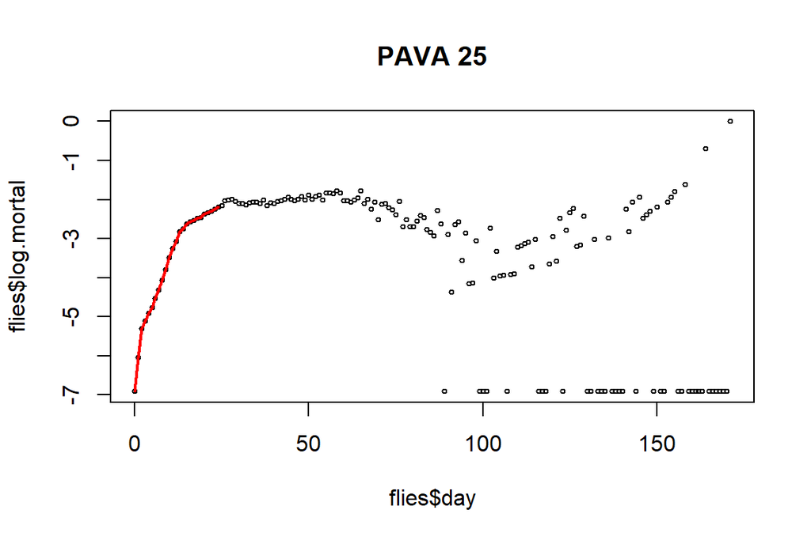

```r
library(Iso)
flies = read.delim("flies.dat", sep="")
err = 0.001
flies$log.mortal = log(flies$mort.rate + err)

iso.25 = pava(flies$log.mortal[1:25])
iso.50 = pava(flies$log.mortal[1:50])
iso.75 = pava(flies$log.mortal[1:75])
iso.85 = pava(flies$log.mortal[1:85])
plot(flies$day, flies$log.mortal, type="p", cex=0.5, lty="dashed",
     main="PAVA 25")
lines(flies$day[1:25], iso.25, type="l", col="red", lwd=2)
```

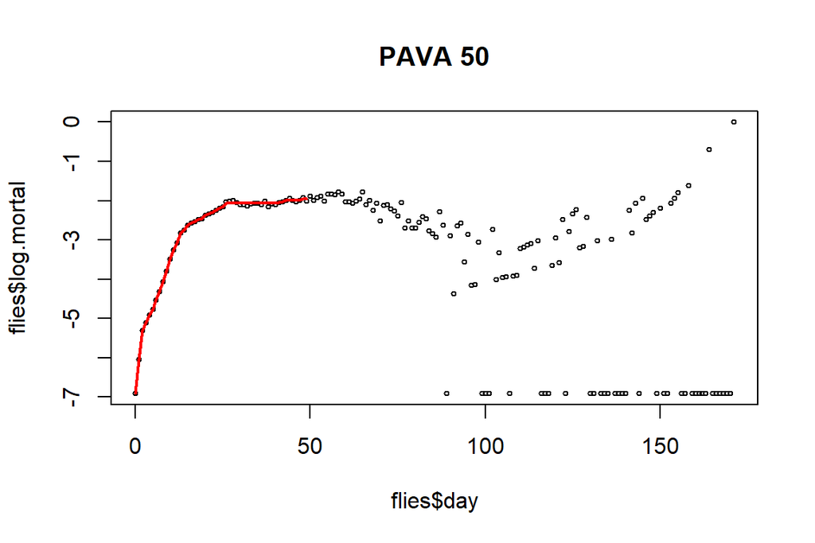

```r
plot(flies$day, flies$log.mortal, type="p", cex=0.5, lty="dashed",
     main="PAVA 50")
lines(flies$day[1:50], iso.50, type="l", col="red", lwd=2)
```

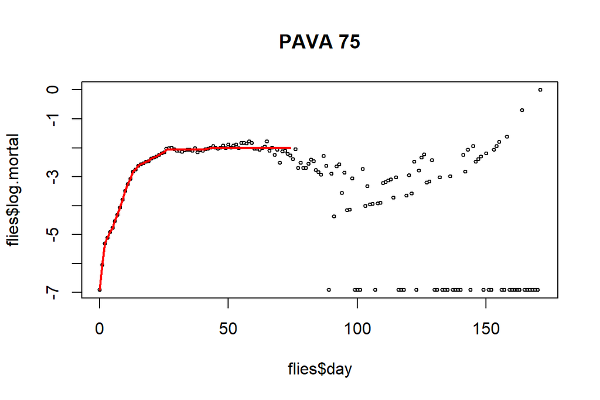

```r
plot(flies$day, flies$log.mortal, type="p", cex=0.5, lty="dashed",
     main="PAVA 75")
lines(flies$day[1:75], iso.75, type="l", col="red", lwd=2)
```

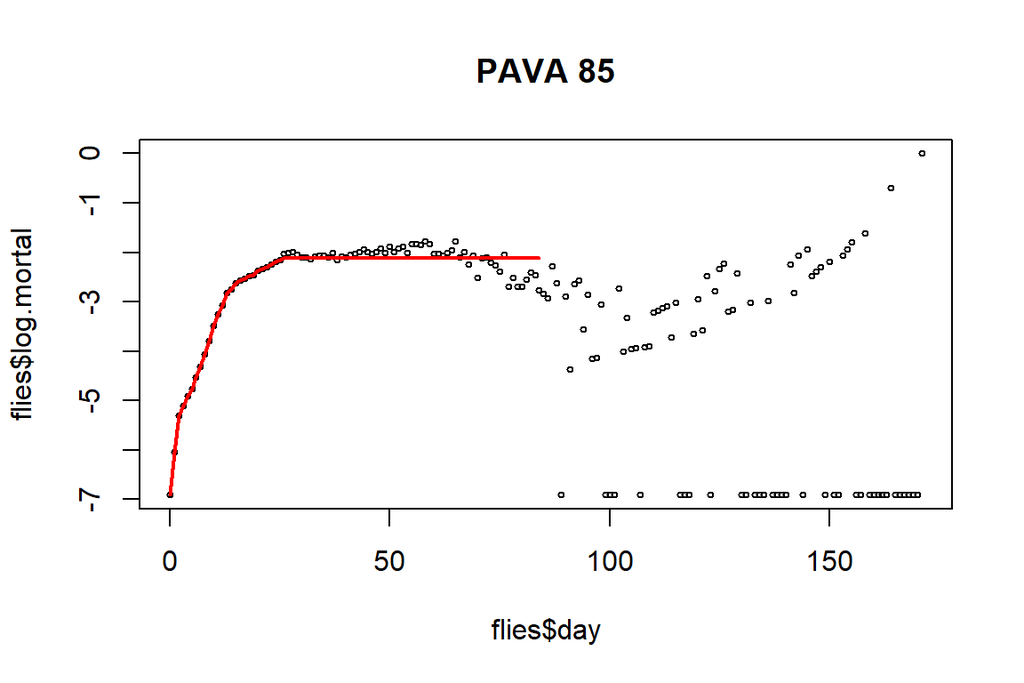

```r
plot(flies$day, flies$log.mortal, type="p", cex=0.5, lty="dashed",
     main="PAVA 85")
lines(flies$day[1:85], iso.85, type="l", col="red", lwd=2)
```

The fit is very good until when the log mortality rate decreases (especially in the last 2 plots). It only starts to drop in performance when the points are no longer monotonic increasing, and hence the regression is forced to be straight with a 0 gradient.

## b. Local Linear Smoother

Next, we will fit a nonparametric smoother where the response is log-mortality rate.

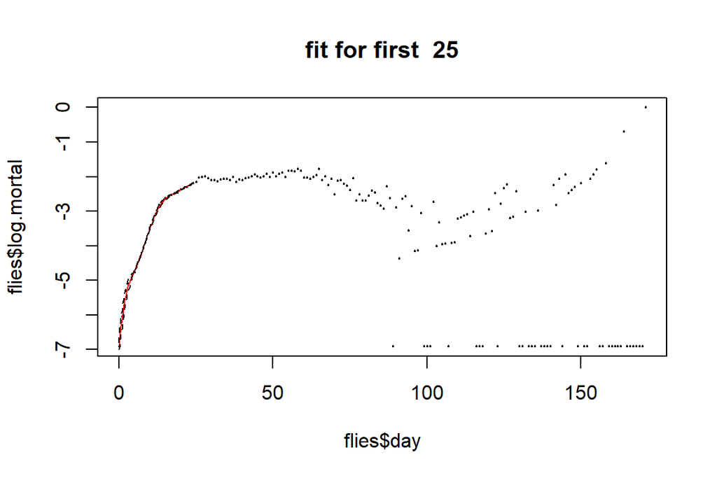

```r
#Define functiion
smoothing = function(n) {
  bw.mat = seq(1,20, length=20)
  loocv.score = NULL
  for (h in bw.mat) {
    fit <- locfit(flies$log.mortal[1:n]~ flies$day[1:n],
                  alpha = c(0,h), deg = 1, ev = dat())
    e = residuals(fit)
    infl = fitted(fit, what="infl")
    score = mean((e/(1-infl))^2)
    loocv.score = c(loocv.score, score)
  }
  optband = bw.mat[which.min(loocv.score)]
  final.fit = locfit(flies$log.mortal[1:n] ~ flies$day[1:n], alpha=c(0, optband), deg=1, maxk=10000)

  plot(flies$day, flies$log.mortal, type="p", cex=0.2,
       main=paste("fit for first ", n))
  plot(final.fit, band="local", type="l", col="red", lwd=5, add=T)
}

smoothing(25)
```

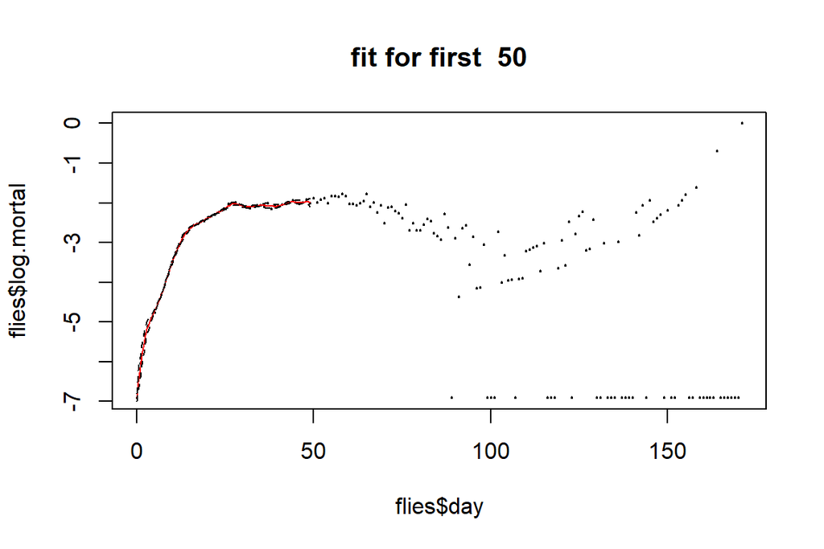

```r
smoothing(50)
```

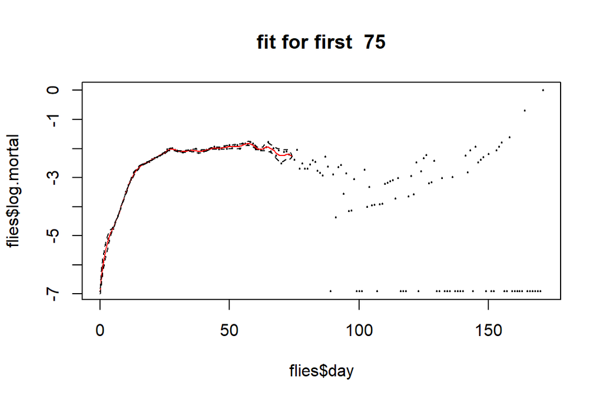

```r
smoothing(75)
```

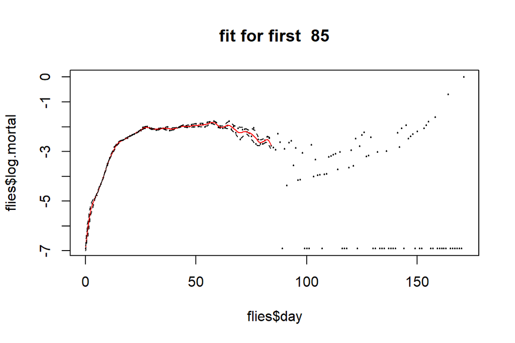

```r
smoothing(85)
```

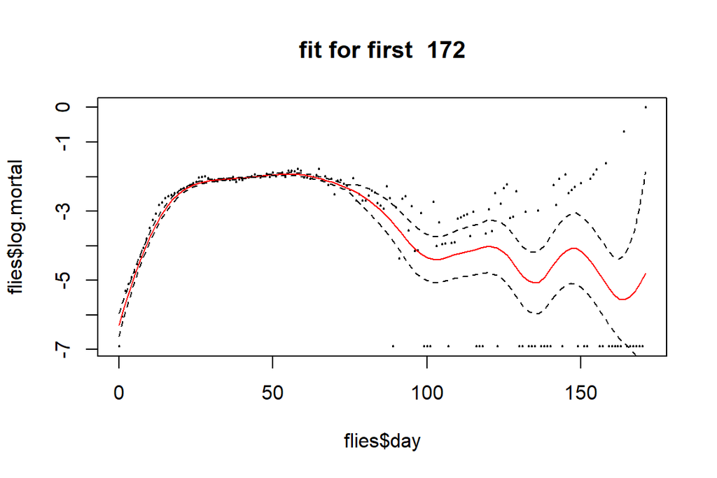

```r
smoothing(length(flies$day))
```

The Confidence bands are the dotted lines around the fitted line in red.

Observe that the confidence interval and the fitted line fits the points very well for n<= 85, but for the entire dataset, the fit starts to drop in performance, as the interval did not contain the points after n=125.

## c. Wavelet Regression

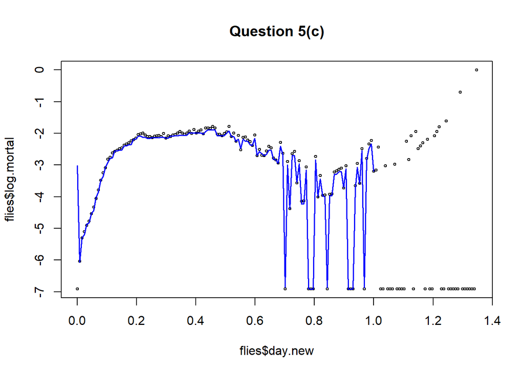

```r
#Define the important parts of wavelet
phi.h = function(x) {if ((x < 0) | (x > 1)) return (0); return (1)}
psi.h = function(x) {if ((x <= 0) | (x > 1)) return (0); if (x <= .5) return (-1); return(1)}
phi = function(x) { apply (as.matrix (x), 1, phi.h)}
psi = function(x) { apply (as.matrix (x), 1, psi.h)}
psi.jk = function(j,k,x) {2^{j/2}*psi((2^j)*x - k)}
beta.jk = function(j,k,funcy,N =127) {
  coef = sapply(k, function(x) psi.jk(j,x,0:N/N) %*% funcy * 1/(N+1))
  return (coef)
}
alpha.coef = function(Y,N =127) {
  coef = phi(0:N/N) %*% Y * 1/(N +1)
  return (as.numeric(coef))
}

wavelet.transform = function(funcy,J,x) {
  alpha = alpha.coef(funcy)
  fhat = apply(as.matrix(x), 1, function(x) {alpha*phi(x)})
  for (j in 0:J) {
    beta = beta.jk(j ,0:(2^j -1) ,funcy)
    for (i in 1:length (x)) {
      fhat[i] = fhat[i] + sum(beta*psi.jk(j ,0:(2^j -1) ,x[i]))
    }
  }
  return (fhat)
}
beta.estimate.dev <- function (beta ,Y){
  beta_med <- median(beta)
  beta <- abs (beta - beta_med)
  sqrt(length(Y))* median(beta)/ 0.6745
}
soft.thres <- function(val, lambda) {
  if(abs(val) <= lambda) return (0)
  else if(val > lambda) return (val - lambda)
  else return (val + lambda)
}

#Sureshrink estimator method
#Used in next portion
sureshrink.thing <- function(lambda, var, n, beta, J) {
  sum(var/n - 2*var/n*(abs(beta) <= lambda) +
          sapply(beta, function(x) min(x^2, lambda^2)))
}

wavelet.ss <- function(x, funcy, J){
  alpha = alpha.coef(funcy)
  fhat = apply(as.matrix(x), 1, function(x) {alpha*phi(x)})

  beta <- beta.jk(J-1 ,0:(2^(J-1)-1) ,funcy)
  var_est <- beta.estimate.dev(beta ,funcy)
  var_est <- var_est ^2
  n <- length(funcy)
  for (j in 0:(J-1)) {
    nj <- 2^j
    beta <- beta.jk(j, 0:(2^j -1) , funcy)
    if(j == 0) {
      lambda <- 0
    }
    else {
      lambda <- optimize(function(l) sureshrink.thing(l, var_est, n, beta , J),
                         c(0, sqrt(var_est / nj*2* log(nj))))$minimum
    }
    beta <- sapply(beta, function(y) soft.thres(y, lambda))
    for (i in 1:length(x)) {
      fhat[i] = fhat[i] + sum(beta*psi.jk(j ,0:(2^j -1),x[i]))
    }
  }
  return (fhat)
}

flies$day.new <- flies$day/127
flies.wavelet.fit = wavelet.ss( flies$day.new[1:128], flies$log.mortal[1:128], 7)
plot(flies$day.new, flies$log.mortal, type="p", cex=0.5, lty="dashed",
     main="Question 5(c)")
lines(flies$day.new[1:128], flies.wavelet.fit, type="l", col="blue", lwd=1.5)
```

Here, notice that the fitted function fits the significant majority of the data very well. This is expected due to the spatial adaptiveness of wavelets. Instead of finding a balance between variance and bias, wavelet regression tries to fit the data well, cause significant and rapid drops in the graph, when the observation response (mortality) = 0.

## d. Wavelet Regression - Daubechies wavelets

Now, let’s consider using the Daubechies wavelets.

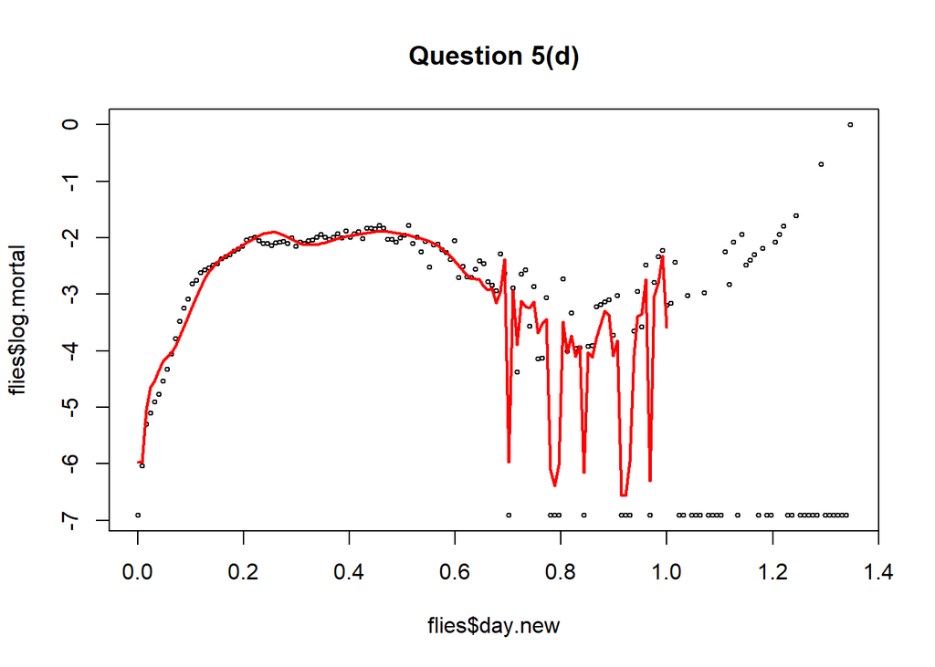

```r
library (wavethresh)
wmap = wd(flies$log.mortal[1:128], family="DaubLeAsymm", filter.number=8)
threshwmap = threshold(wmap, type="soft", policy="universal")
yhat = wr(threshwmap)

plot(flies$day.new, flies$log.mortal, type="p", cex=0.5, lty="dashed",
     main="Question 5(d)")
lines(flies$day.new[1:128], yhat, type="l", col="red", lwd=2)
```